# Logistic Regression

## Data exploration

In this data analysis we are going to use a data set from [UCI Machine Learning Repository] (https://archive.ics.uci.edu/ml/datasets/Student+Performance#). This data set was originally aimed to predict student performance on Math and Portuguese Language subjects in secondary education (high school). This also includes information about alcohol consumption.

For this exercise, we are going to explore relationship between alcohol consumption and other parameters available. There are two separate data sets from this website, but we are going to use the combined data set. This joined data set can be access throuhg this link: http://s3.amazonaws.com/assets.datacamp.com/production/course_2218/datasets/alc.txt

```r
library(dplyr)
url <- "http://s3.amazonaws.com/assets.datacamp.com/production/course_2218/datasets/alc.txt"

# read the data

data<-read.table(url, sep = ",", header = TRUE)
```

```r
str(data)
dim(data)
glimpse(data)
colnames(data)
```

The data set contains 382 observations and 35 covariates. Two new columns were added to the original data set (**$alc_use** and **$high_use**). **alc_use** is the average alcohol consumption during workday (**$Dalc**) and weekend (**$Walc**). **high_use** is a logical column which contains boolean data type (TRUE or FALSE).

## Graphical exploration

On this exercise, we are going to explore relationship of alcohol consumption (**high_use**) to **failures**, **absences**, **freetime**. **sex**.

**failures** = number of past class failures  
**Hypothesis**: Failing a subject could motivate the student to drink more, and the more subject they fail, the more alcohol they consumes.  
Alternatively, **failures** is also a proxy for success. The less failed subjects they had, the more subjects they did not fail. This might also caused alcohol consumption.

**Note**: The exploration also look at the possible effect of sex to alcohol consumption due to failing subjects.

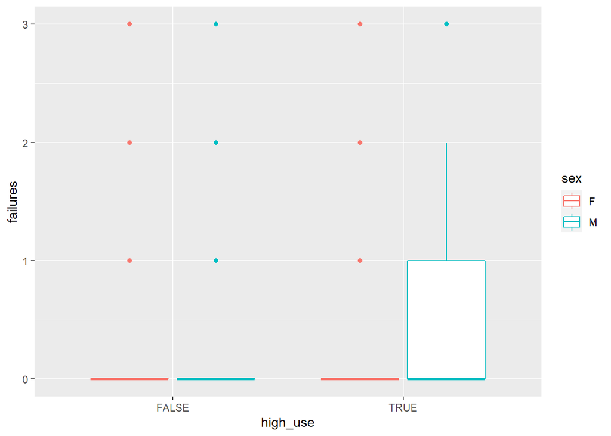

```r
library(ggplot2)
library(dplyr)

g1 <- ggplot(data, aes(x = high_use, y = failures, col = sex))

# define the plot as a boxplot and draw it
g1 + geom_boxplot() + ylab("failures")
```

```r
data %>% group_by(failures, sex, high_use) %>% summarise(count = n())
```

```
## # A tibble: 16 x 4
## # Groups:   failures, sex [8]
##    failures sex   high_use count
##       <int> <chr> <lgl>    <int>
##  1        0 F     FALSE      136
##  2        0 F     TRUE        32
##  3        0 M     FALSE       98
##  4        0 M     TRUE        50
##  5        1 F     FALSE       14
##  6        1 F     TRUE         2
##  7        1 M     FALSE        8
##  8        1 M     TRUE        14
##  9        2 F     FALSE        3
## 10        2 F     TRUE         5
## 11        2 M     FALSE        2
## 12        2 M     TRUE         1
## 13        3 F     FALSE        4
## 14        3 F     TRUE         2
## 15        3 M     FALSE        5
## 16        3 M     TRUE         6
```

Next,  
**absences** = number of school absences  
**Hypothesis** = The number of absences might indicate more alcohol consumption.

**NOTE**: The exploration also includes the effect of sex in the relationship of high alcohol consumption and number of absences.

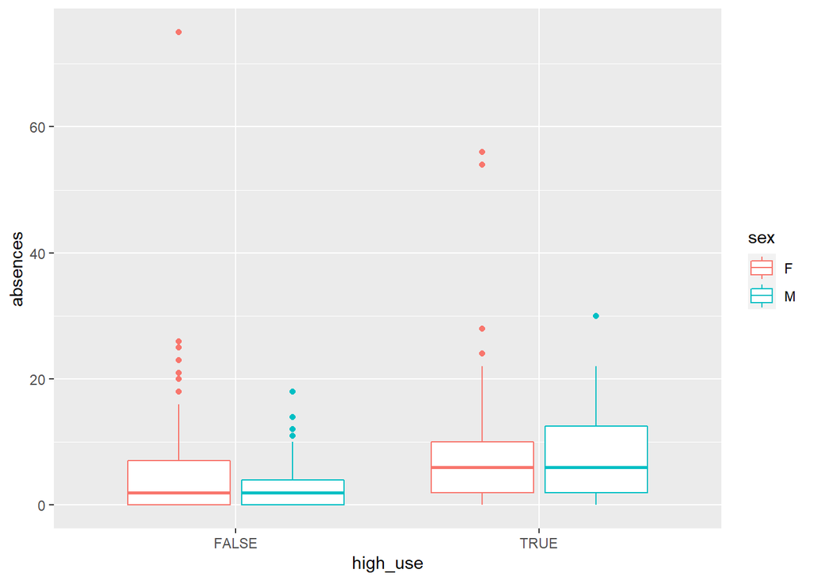

```r
g2 <- ggplot(data, aes(x = high_use, y = absences, col = sex))

# define the plot as a boxplot and draw it
g2 + geom_boxplot() + ylab("absences")
```

The resulting graph shows students with more absences have higher alcohol consumption, however difference between sexes is not apparent.

```r
data %>% group_by(absences, sex, high_use) %>% summarise(count = n())
```

```
## # A tibble: 74 x 4
## # Groups:   absences, sex [50]
##    absences sex   high_use count
##       <int> <chr> <lgl>    <int>
##  1        0 F     FALSE       55
##  2        0 F     TRUE         7
##  3        0 M     FALSE       39
##  4        0 M     TRUE        15
##  5        1 F     FALSE        1
##  6        1 F     TRUE         1
##  7        1 M     FALSE        1
##  8        2 F     FALSE       24
##  9        2 F     TRUE         8
## 10        2 M     FALSE       30
## # ... with 64 more rows
```

Finally, **freetime** = free time after school. **Hypothesis**: The more free time the students have the more alcohol they consumes.

*NOTE**: The effect of sex to the relationship of alcohol consumption and free time is also explored.

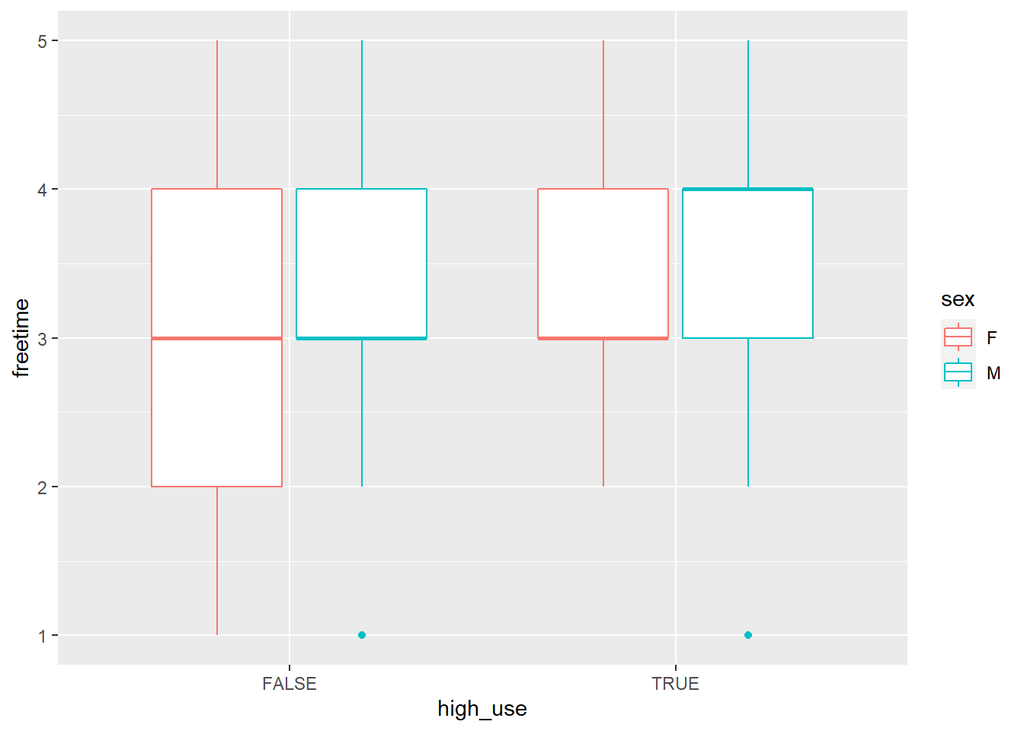

```r
g3 <- ggplot(data, aes(x = high_use, y = freetime, col = sex))

# define the plot as a boxplot and draw it
g3 + geom_boxplot() + ylab("freetime")
```

```r
data %>% group_by(freetime, sex, high_use) %>% summarise(count = n())
```

```
## # A tibble: 19 x 4
## # Groups:   freetime, sex [10]
##    freetime sex   high_use count
##       <int> <chr> <lgl>    <int>
##  1        1 F     FALSE       14
##  2        1 M     FALSE        2
##  3        1 M     TRUE         2
##  4        2 F     FALSE       30
##  5        2 F     TRUE         5
##  6        2 M     FALSE       17
##  7        2 M     TRUE        10
##  8        3 F     FALSE       72
##  9        3 F     TRUE        19
## 10        3 M     FALSE       44
## 11        3 M     TRUE        21
## 12        4 F     FALSE       35
## 13        4 F     TRUE        15
## 14        4 M     FALSE       34
## 15        4 M     TRUE        25
## 16        5 F     FALSE        6
## 17        5 F     TRUE         2
## 18        5 M     FALSE       16
## 19        5 M     TRUE        13
```

Overall, we can further explore the relationship of **failures**, **absences**, **freetime** and **sex** by fitting a model.

## Fitting a model

For this exercise, we are going to use **glm()** function to fit a model to test relationship between high alcohol consumption and **failures**, **absences**, **freetime** and **sex**. The first model also includes interaction of sex with the first three explanatory variable.

```r
## fitting model using glm()
m1 <- glm(high_use ~ failures*sex + absences*sex + freetime*sex,
          data = data, family = "binomial")

#-- print out a summary of the model
summary(m1)
```

```
##
## Call:
## glm(formula = high_use ~ failures * sex + absences * sex + freetime *
##     sex, family = "binomial", data = data)
##
## Deviance Residuals:
##     Min       1Q   Median       3Q      Max
## -1.8748  -0.7712  -0.5805   0.8336   2.0780
##
## Coefficients:
##               Estimate Std. Error z value Pr(>|z|)
## (Intercept)   -3.65893    0.75978  -4.816 1.47e-06 ***
## failures       0.50014    0.23309   2.146  0.03190 *
## sexM           2.00416    0.99171   2.021  0.04329 *
## absences       0.04276    0.01717   2.490  0.01277 *
## freetime       0.59747    0.21222   2.815  0.00487 **
## failures:sexM -0.07163    0.31644  -0.226  0.82091
## sexM:absences  0.12078    0.03932   3.072  0.00213 **
## sexM:freetime -0.52767    0.27406  -1.925  0.05418 .
## ---
## Signif. codes:  0 '***' 0.001 '**' 0.01 '*' 0.05 '.' 0.1 ' ' 1
##
## (Dispersion parameter for binomial family taken to be 1)
##
##     Null deviance: 462.21  on 381  degrees of freedom
## Residual deviance: 398.66  on 374  degrees of freedom
## AIC: 414.66
##
## Number of Fisher Scoring iterations: 4
```

Based on this model, there is no significant linear relationship between **failure-sex** and high alcohol consumption. Furthermore, **freetime-sex** has very low significant effect to high alcohol consumption.  
Lets do some model selection using **drop1**.

```r
#-- Model selection
drop1(m1)
```

```
## Single term deletions
##
## Model:
## high_use ~ failures * sex + absences * sex + freetime * sex
##              Df Deviance    AIC
## <none>            398.66 414.66
## failures:sex  1   398.71 412.71
## sex:absences  1   409.06 423.06
## sex:freetime  1   402.47 416.47
```

Based on **AIC** values, we can drop **failures-sex** to improve the predictive capacity of the model.

Let us run the new model (**m2**)which does not have **failures-sex** as an explanatory variable.

```r
#-- print out the coefficients of the model
m2<- glm(high_use ~ failures + absences*sex + freetime*sex,
         data = data, family = "binomial")
summary(m2)
```

```
##
## Call:
## glm(formula = high_use ~ failures + absences * sex + freetime *
##     sex, family = "binomial", data = data)
##
## Deviance Residuals:
##     Min       1Q   Median       3Q      Max
## -1.8722  -0.7682  -0.5845   0.8355   2.0697
##
## Coefficients:
##               Estimate Std. Error z value Pr(>|z|)
## (Intercept)   -3.62942    0.74603  -4.865 1.14e-06 ***
## failures       0.46128    0.15826   2.915  0.00356 **
## absences       0.04272    0.01717   2.488  0.01284 *
## sexM           1.98088    0.98484   2.011  0.04429 *
## freetime       0.59264    0.21064   2.814  0.00490 **
## absences:sexM  0.12148    0.03930   3.091  0.00199 **
## sexM:freetime -0.52886    0.27376  -1.932  0.05338 .
## ---
## Signif. codes:  0 '***' 0.001 '**' 0.01 '*' 0.05 '.' 0.1 ' ' 1
##
## (Dispersion parameter for binomial family taken to be 1)
##
##     Null deviance: 462.21  on 381  degrees of freedom
## Residual deviance: 398.71  on 375  degrees of freedom
## AIC: 412.71
##
## Number of Fisher Scoring iterations: 4
```

```r
#-- model selection
drop1(m2)
```

```
## Single term deletions
##
## Model:
## high_use ~ failures + absences * sex + freetime * sex
##              Df Deviance    AIC
## <none>            398.71 412.71
## failures      1   407.00 419.00
## absences:sex  1   409.21 421.21
## sex:freetime  1   402.54 414.54
```

Model **m2** have lower AIC value after **drop1()**. This is still the best model so far, with almost all explanatory variable having significant linear correlation with high alcohol consumption.

Let us stuck with this model and further explore the results.

```r
# compute odds ratios (OR)
OR <- coef(m2) %>% exp

# compute confidence intervals (CI)
CI <- confint(m2) %>% exp
# print out the odds ratios with their confidence intervals
cbind(OR, CI)
```

```
##                       OR       2.5 %     97.5 %
## (Intercept)   0.02653166 0.005624733  0.1059779
## failures      1.58609902 1.161286045  2.1693083
## absences      1.04364576 1.008744304  1.0820700
## sexM          7.24908868 1.080292144 52.1118881
## freetime      1.80875631 1.211856934  2.7780692
## absences:sexM 1.12917143 1.048102129  1.2237126
## sexM:freetime 0.58927770 0.341091518  1.0006724
```

We can test the predictive capacity of the model using the results from model **m2**.

```r
# print out the coefficients of the model
m2<- glm(high_use ~ failures + absences*sex + freetime*sex,
         data = data, family = "binomial")

# predict() the probability of high_use
probabilities <- predict(m2, type = "response")

# add the predicted probabilities to 'alc'
data <- mutate(data, probability = probabilities)

# use the probabilities to make a prediction of high_use
data <- mutate(data, prediction = probabilities > 0.5)

# see the last ten original classes, predicted probabilities, and class predictions
select(data, failures, absences, sex, high_use, probability, prediction) %>% tail(10)
```

```
##     failures absences sex high_use probability prediction
## 373        1        0   M    FALSE  0.26974475      FALSE
## 374        1       14   M     TRUE  0.79685020       TRUE
## 375        0        2   F    FALSE  0.14603326      FALSE
## 376        0        7   F    FALSE  0.27691468      FALSE
## 377        1        0   F    FALSE  0.31054319      FALSE
## 378        0        0   F    FALSE  0.13569710      FALSE
## 379        1        0   F    FALSE  0.07073197      FALSE
## 380        1        0   F    FALSE  0.07073197      FALSE
## 381        0        3   M     TRUE  0.28888590      FALSE
## 382        0        0   M     TRUE  0.19886333      FALSE
```

```r
# tabulate the target variable versus the predictions
table(high_use = data$high_use, prediction = data$prediction)
```

```
##         prediction
## high_use FALSE TRUE
##    FALSE   251   19
##    TRUE     78   34
```

```r
table(data$high_use)
```

```
##
## FALSE  TRUE
##   270   112
```

The model is good in predicting low alcohol consumption than high alcohol consumption. The model still needs improvement.

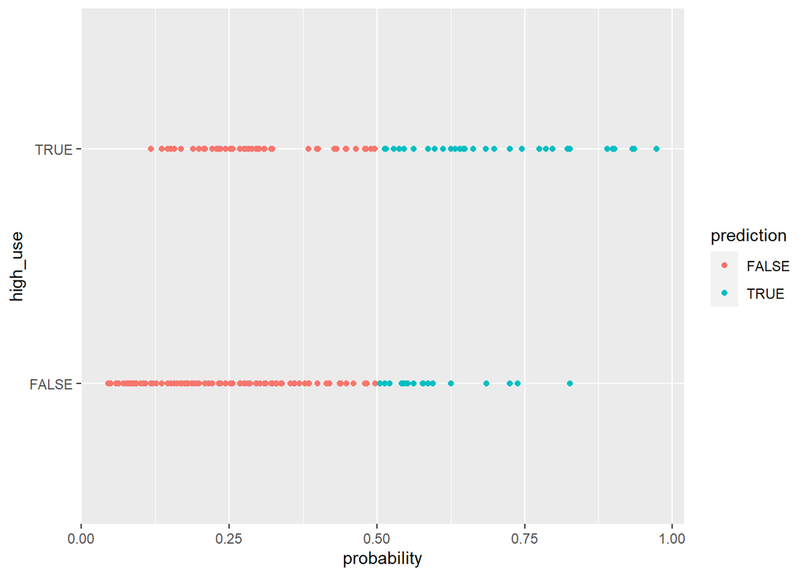

```r
# initialize a plot of 'high_use' versus 'probability' in 'alc'
g <- ggplot(data, aes(x = probability, y = high_use, col = prediction))

# define the geom as points and draw the plot
g + geom_point()
```

```r
# tabulate the target variable versus the predictions
table(high_use = data$high_use, prediction = data$prediction) %>% prop.table() %>% addmargins()
```

```
##         prediction
## high_use      FALSE       TRUE        Sum
##    FALSE 0.65706806 0.04973822 0.70680628
##    TRUE  0.20418848 0.08900524 0.29319372
##    Sum   0.86125654 0.13874346 1.00000000
```

```r
# define a loss function (mean prediction error)
loss_func <- function(class, prob) {
  n_wrong <- abs(class - prob) > 0.5
  mean(n_wrong)
}

# call loss_func to compute the average number of wrong predictions in the (training) data
loss_func(class = data$high_use, prob = data$probability)
```

```
## [1] 0.2539267
```

```r
# K-fold cross-validation
library(boot)
cv <- cv.glm(data = data, cost = loss_func, glmfit = m2, K = 10)

# average number of wrong predictions in the cross validation
cv$delta[1]
```

```
## [1] 0.2591623
```